The R package ‘igraph’ allows for graphs to be generated using algorithms and improves the ability of R to handle extremely large graphs. Another powerful use of iGraph is the direct implementation of data frames as graphs.

Dependencies: The igraph package requires that irlba and pkgconfig

Basic arguments of graph function:

–Types of basic plot functions:: There are several ways which a plot can be created in this package. One method uses ‘graph_from_literal’. This function requires a formula which shows each vertex and its connection to other vertices in the plot. A useful feature of igraph is the ability to directly convert a data frame to a graph, using the ‘graph_from_data_frame’ function. Other functions are ‘graph_from_edgelist’, and ‘graph_from_adjacency_matrix’.

–Vertices/Edges: Verticies are points within the graph, and edges are the lines which connect each vertex. The basic graph function allows the number of verticies to be specified. Alternatively, some igraph functions allow a dataframe or list of vertices and/or edges to  
be passed into the function to create a graph.

–Directed/Undirected:: There are two main different types of iGraphs. The first is undirected and the other is directed; Undirected means that the edges don’t specify a direction for the connection between verticies. Directed graphs specify a single path between verticies. By default, the ‘directed’ arguement is TRUE. –Simplify: This argument takes TRUE or FALSE as its input (TRUE by default). If the value is TRUE, then the graph will not allow and edge to connect both of its endpoints to a single vertex. A simplified graph also prevents multiple edges; this means that it will prevent two edges from having identical endpoints.

Basic iGraph functions: -graph or make_graph -vertex_attr -degree -add.edges -add.vertices -delete.edges -delete.vertices

Basic graph:

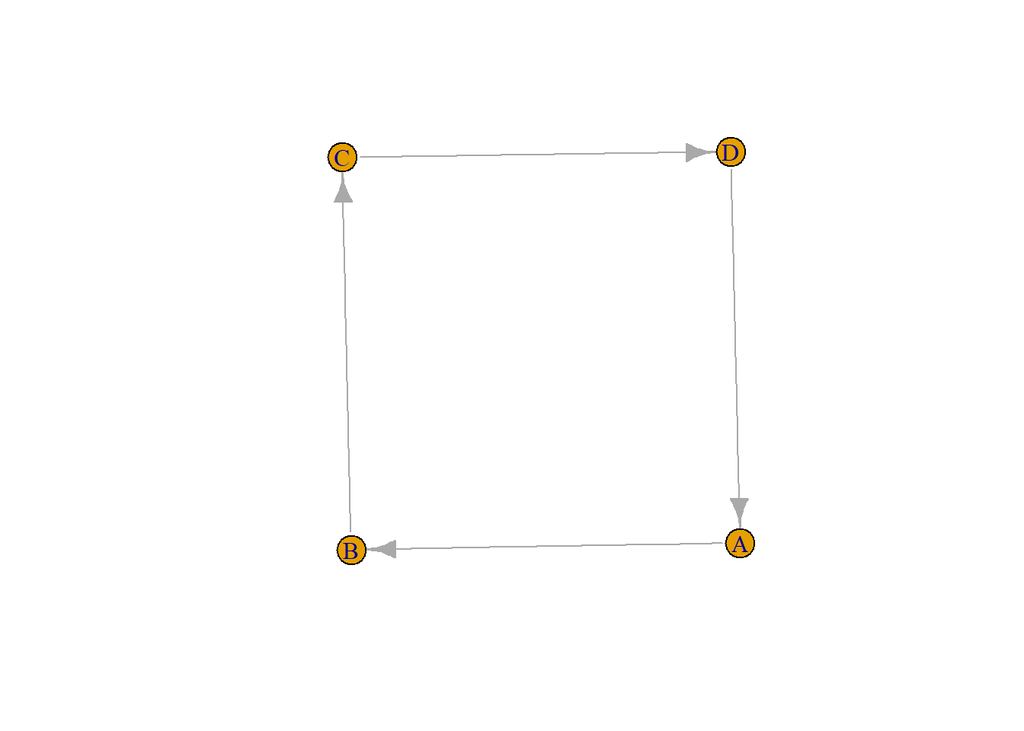

```r
library(igraph)
group <- graph( edges=c('A','B', 'B','C', 'C','D', 'D','A'))
plot(group)
```

-directed vs undirected plots

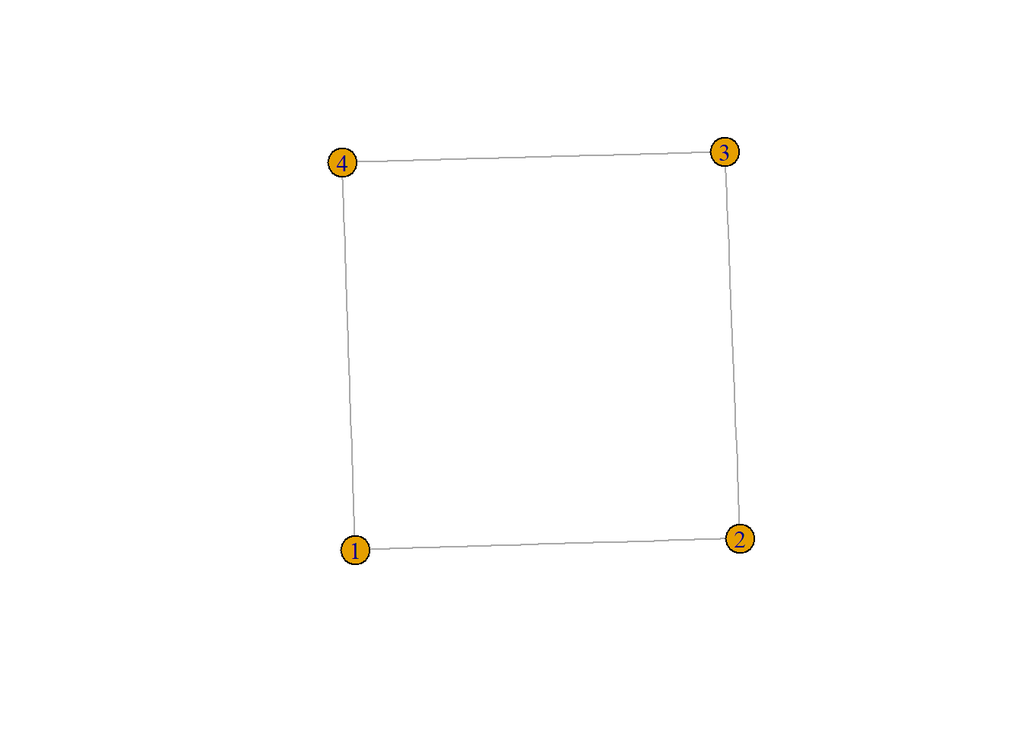

```r
group1 <- graph( edges=c(1,2, 2,3, 3,4, 4,1), directed=F )
plot(group1)
```

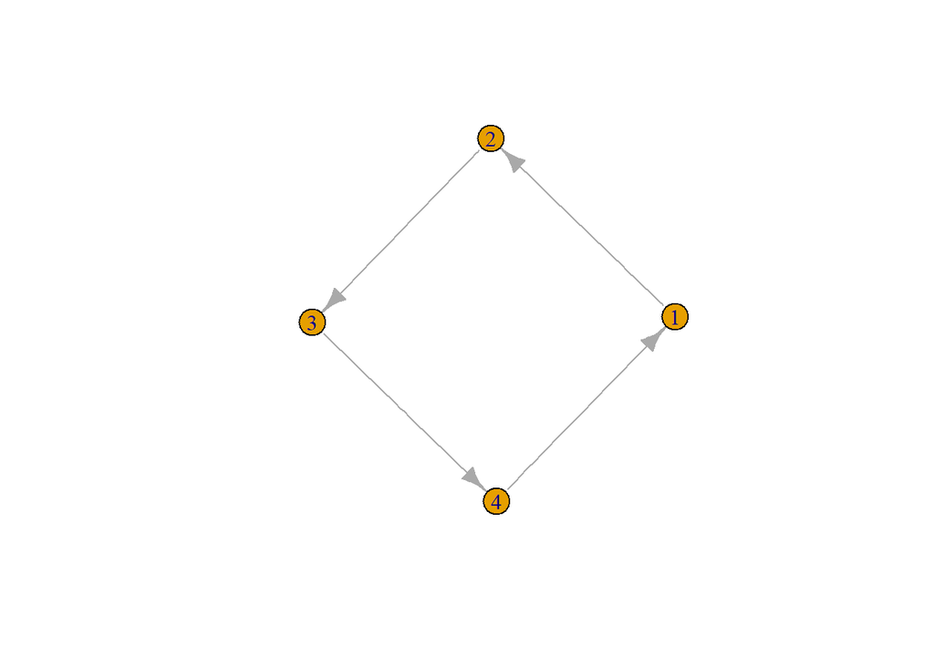

```r
group2 <- graph( edges=c(1,2, 2,3, 3,4, 4,1), directed=T)
plot(group2)
```

The parameter n can specify the number of vertices for a graph when the edges are numeric and will affect the plot when n is at least equal to the number of edges specified

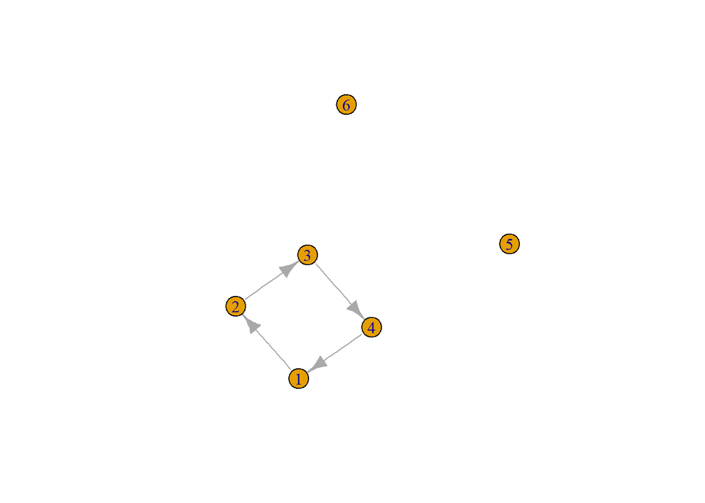

```r
group3 <- graph(edges=c(1,2, 2,3, 3,4, 4,1), n=6)
plot(group3)
```

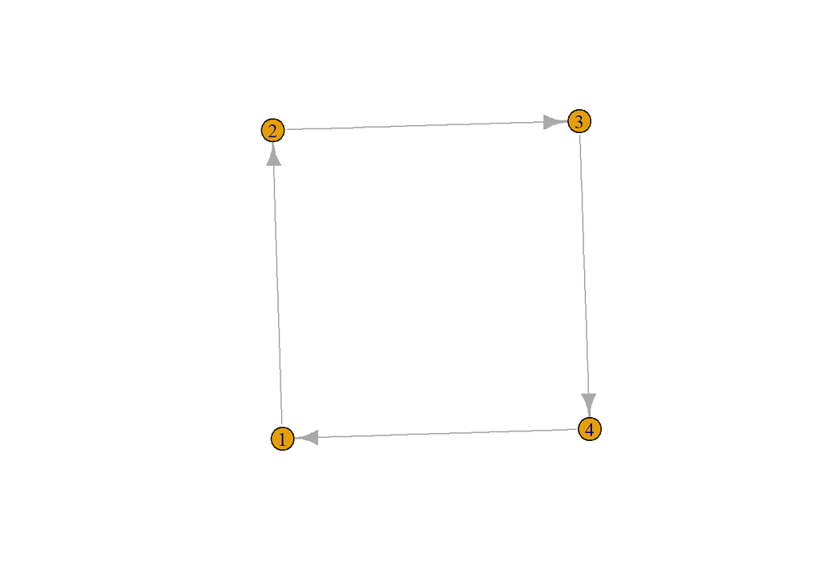

```r
group4 <- graph(edges=c(1,2, 2,3, 3,4, 4,1), n=3)
plot(group4) # produces same result as first graphs
```

Plot generated from a data frame:

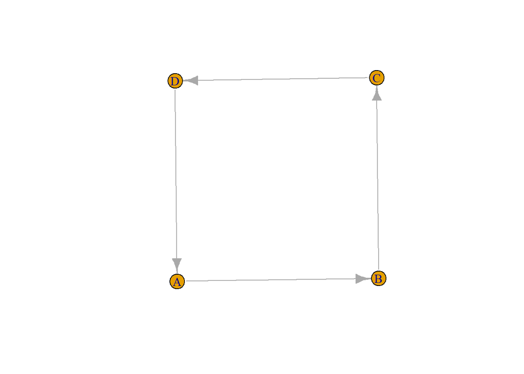

```r
edges = data.frame(x = c('A','B','C','D'), y = c('B','C','D','A'))
graph1 <- graph_from_data_frame(edges)
plot(graph1)
```

Plot generated from graph_from_literal:

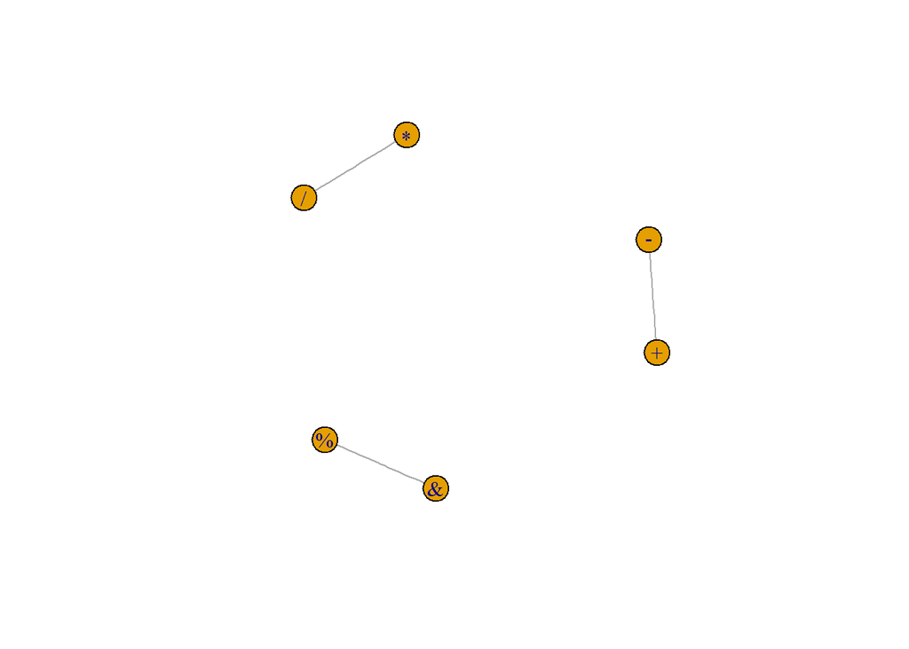

```r
graph2 <- graph_from_literal( "+" -- "-", "*" -- "/", "%" -- "&" )
plot(graph2)
```

Plot generated from edgelist:

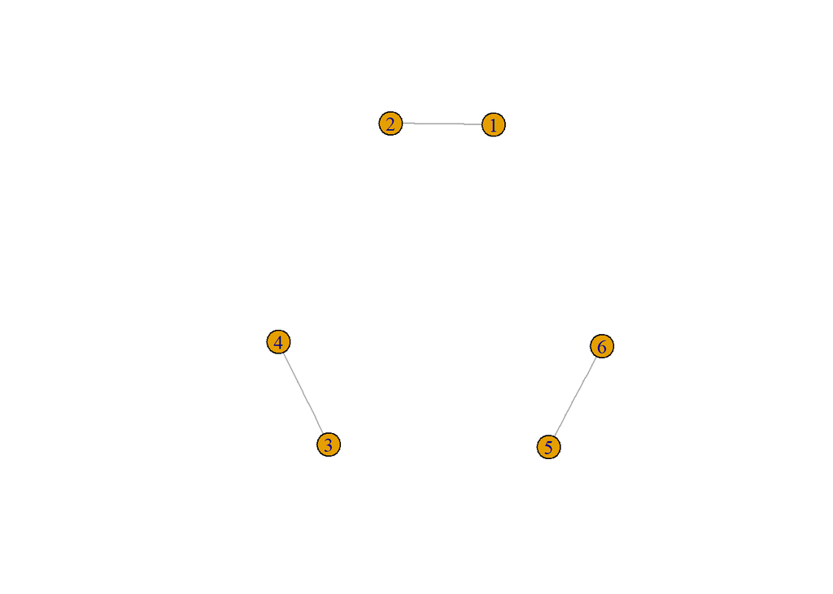

```r
edgelist = matrix(c(1, 2, 3, 4, 5, 6), ncol = 2, byrow = TRUE)
graph3 <- graph_from_edgelist(edgelist, directed = FALSE)
plot(graph3)
```

Plot generated from adjacency matrix: Note: This matrix must be square.

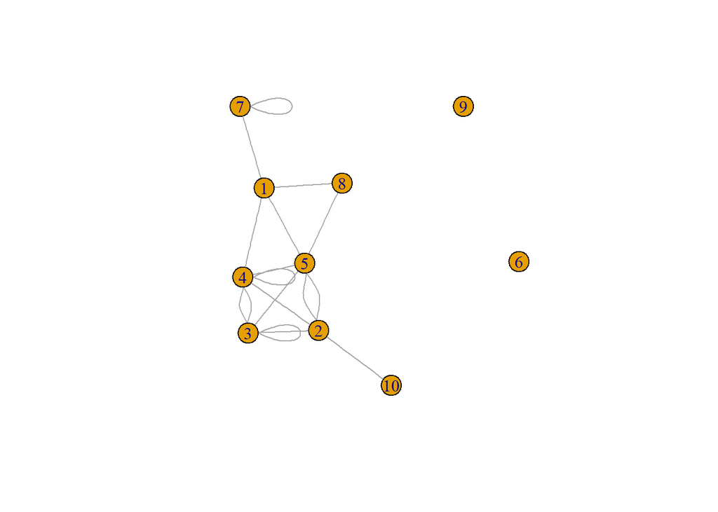

```r
adjm <- matrix(rnorm(100,0,1), nrow=10, ncol=10)
graph4<- graph_from_adjacency_matrix(adjmatrix = adjm, mode="undirected")
plot(graph4)
```

Additional Example Plots:

-Empty Plot:

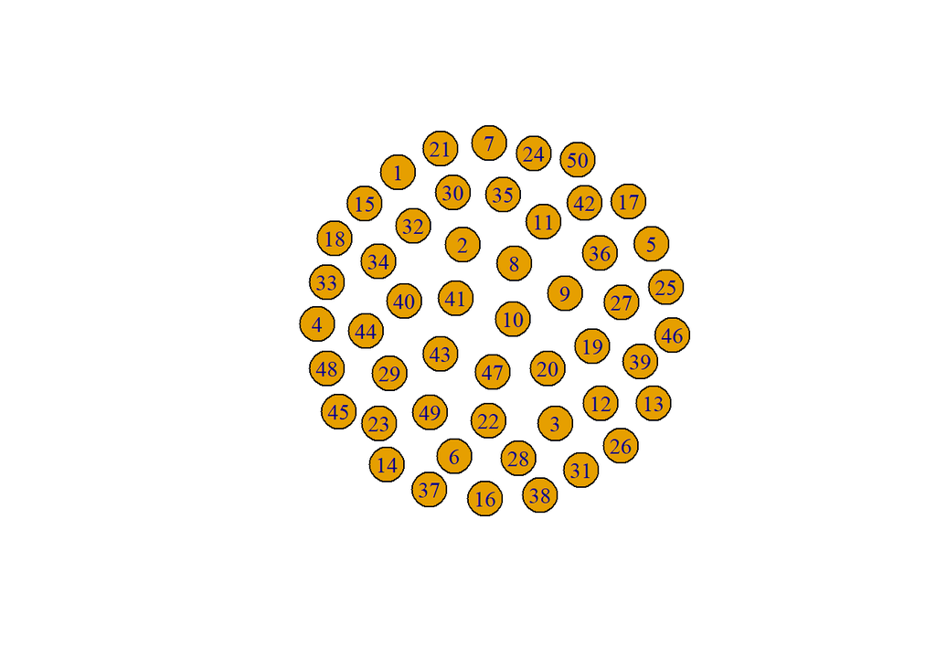

```r
emptyGraph <- make_empty_graph(50)
plot(emptyGraph, vertex.size=20)
```

-Full Graph:

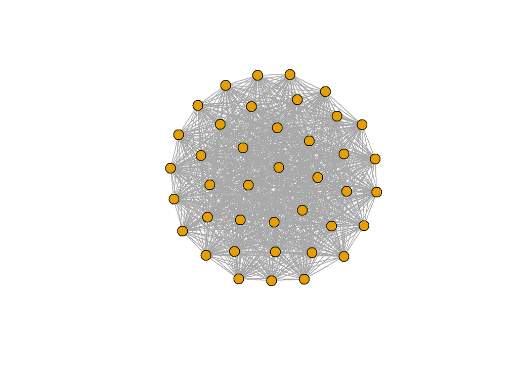

```r
fg <- make_full_graph(40)
plot(fg, vertex.size=10, vertex.label=NA)
```

-Simple Star Graph:

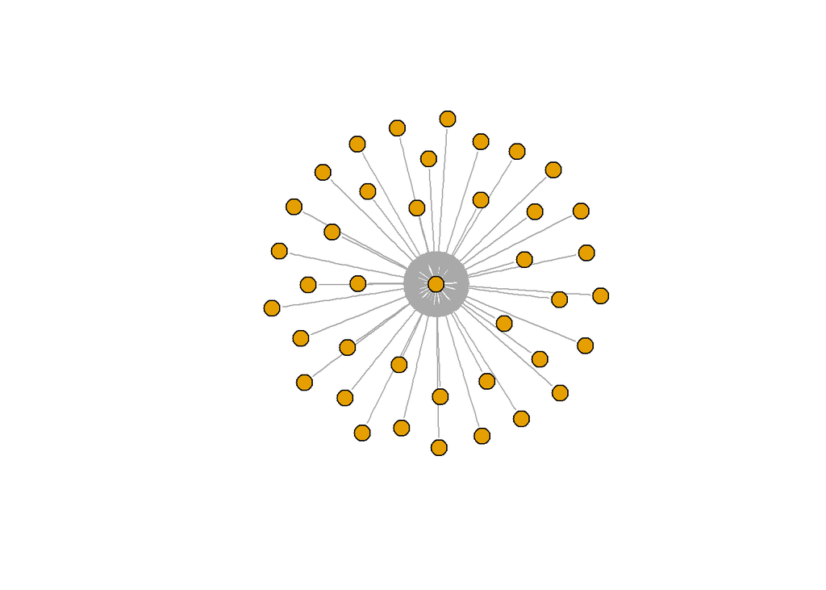

```r
st <- make_star(40)
plot(st, vertex.size=10, vertex.label=NA)
```

-Tree Graph:

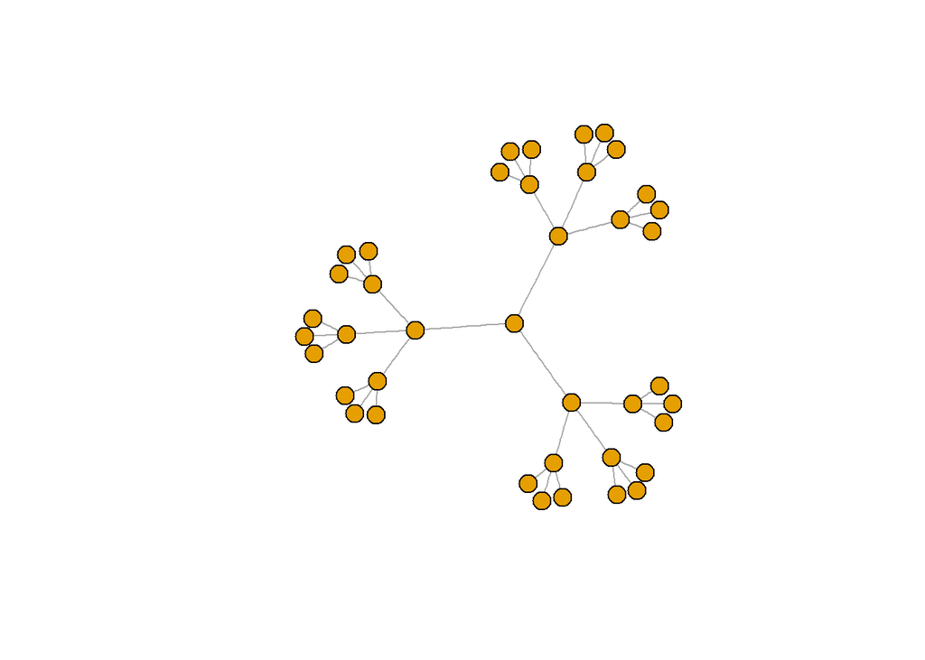

```r
tr <- make_tree(40, children = 3, mode = "undirected")
plot(tr, vertex.size=10, vertex.label=NA)
```

-Ring Graph:

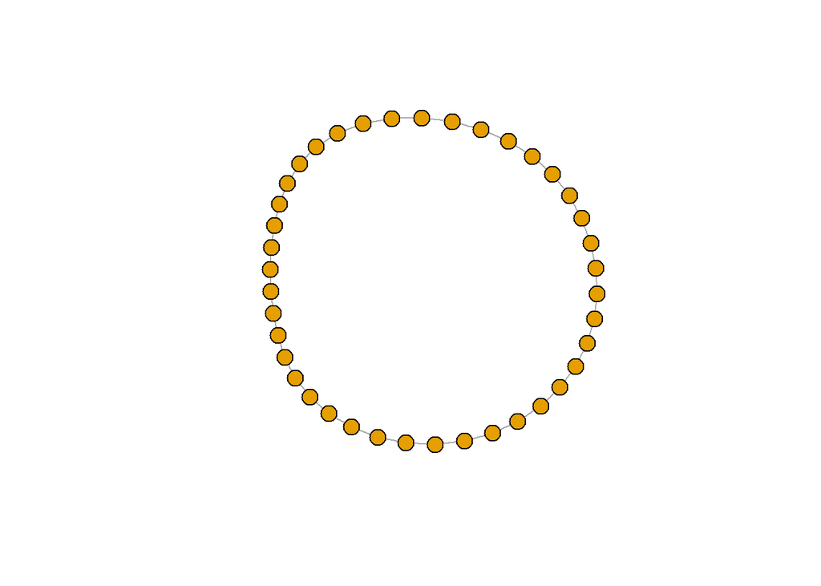

```r
rn <- make_ring(40)
plot(rn, vertex.size=10, vertex.label=NA)
```